# Module 1.5 — Probability & Markov chains

You have already taken a course in linear algebra in your first year; but since it was a while ago, and linear algebra is used everywhere in bioinformatics, here is a recap!

- If you forgot how to solve linear equations by hand then we suggest you go through it again.
- If this seems simple, then at least use this as opportunity to practice using R. You can solve equations using [the R `solve` function](https://www.rdocumentation.org/packages/base/versions/3.6.2/topics/solve).

**Optional reading:** Below roughly summarizes the first 60 pages of [this book](https://personal.math.ubc.ca/~carrell/NB.pdf).

## Recap: Intro

It is likely not an understatement that our civilisation is built upon linear algebra. We will need it to handle confounding factors such as age, sex, BMI, while comparing treatments of samples. However, it is also used to design bridges, track diffusion and heat, and is the basis of quantum mechanics. We won’t cover the latter details, but you will be introduced to the common notation as used in data science, and how to perform basic analysis of the equations. Wikipedia summarizes [linear algebra](https://en.wikipedia.org/wiki/Linear_algebra) but is usually not a good source for learning mathematics alone; it is better for looking up details after you have been introduced to a topic.

## Recap: Solving linear systems

- See this video to learn how to manipulate and solve systems of linear equations; ignore the matrix part for now, which we get to in more detail later. Instead focus on the augmented format and how to get it to the reduced form where you can read out the solution: https://www.youtube.com/watch?v=RgnWMBpQPXk
- Wikipedia also summarises [the method of Gaussian elimination](https://en.wikipedia.org/wiki/Gaussian_elimination).

**Practice linear equation solving:**

### Q1.1

Solve for $x$ and $y$ in: $x+y=1;\ x+2y=2$.

**Step-by-step solution**

Augmented matrix:
$$\left[\begin{array}{cc|c} 1 & 1 & 1 \\ 1 & 2 & 2 \end{array}\right]$$

1. $R_2 \leftarrow R_2 - R_1$:
   $$\left[\begin{array}{cc|c} 1 & 1 & 1 \\ 0 & 1 & 1 \end{array}\right]$$
2. From row 2: $y = 1$.
3. Back-substitute: $x = 1 - y = 0$.

**Answer:** $x = 0,\ y = 1$.

### Q1.2

Solve for $x$ and $y$ in: $x = 1;\ 4x + 4y = 0$ (note: you can still arrange the equations for Gaussian elimination, just leave a “hole” if a variable is missing).

**Step-by-step solution**

Augmented matrix (note the missing $y$ in eq. 1 → 0):
$$\left[\begin{array}{cc|c} 1 & 0 & 1 \\ 4 & 4 & 0 \end{array}\right]$$

1. $R_2 \leftarrow R_2 - 4 R_1$:
   $$\left[\begin{array}{cc|c} 1 & 0 & 1 \\ 0 & 4 & -4 \end{array}\right]$$
2. From row 2: $y = -1$.
3. From row 1: $x = 1$.

**Answer:** $x = 1,\ y = -1$.

### Q1.3

Solve for $x$ and $y$ in: $2x + 4y = 2;\ x + y = 0$.

**Step-by-step solution**

Augmented matrix:
$$\left[\begin{array}{cc|c} 2 & 4 & 2 \\ 1 & 1 & 0 \end{array}\right]$$

1. Swap rows for a friendlier pivot:
   $$\left[\begin{array}{cc|c} 1 & 1 & 0 \\ 2 & 4 & 2 \end{array}\right]$$
2. $R_2 \leftarrow R_2 - 2 R_1$:
   $$\left[\begin{array}{cc|c} 1 & 1 & 0 \\ 0 & 2 & 2 \end{array}\right]$$
3. $y = 1$, then $x = -y = -1$.

**Answer:** $x = -1,\ y = 1$.

### Q1.4

Solve for $x$, $y$ and $z$ in: $3x + 3y + 3z = 3;\ x + 2y + 2z = 2;\ 2x + x + 2z = 2$.

**Step-by-step solution**

The third equation simplifies to $3x + 2z = 2$. Augmented matrix:
$$\left[\begin{array}{ccc|c} 3 & 3 & 3 & 3 \\ 1 & 2 & 2 & 2 \\ 3 & 0 & 2 & 2 \end{array}\right]$$

1. $R_1 \leftarrow R_1 / 3$:
   $$\left[\begin{array}{ccc|c} 1 & 1 & 1 & 1 \\ 1 & 2 & 2 & 2 \\ 3 & 0 & 2 & 2 \end{array}\right]$$
2. $R_2 \leftarrow R_2 - R_1$, $R_3 \leftarrow R_3 - 3 R_1$:
   $$\left[\begin{array}{ccc|c} 1 & 1 & 1 & 1 \\ 0 & 1 & 1 & 1 \\ 0 & -3 & -1 & -1 \end{array}\right]$$
3. $R_3 \leftarrow R_3 + 3 R_2$:
   $$\left[\begin{array}{ccc|c} 1 & 1 & 1 & 1 \\ 0 & 1 & 1 & 1 \\ 0 & 0 & 2 & 2 \end{array}\right]$$
4. Back-substitute: $z = 1$, $y = 1 - z = 0$, $x = 1 - y - z = 0$.

**Answer:** $x = 0,\ y = 0,\ z = 1$.

### Q1.5

Solve for $x$, $y$ and $z$ in: $3x = 3;\ x + 2y + 2z = 0;\ 2x + 2z = 0$.

**Step-by-step solution**

1. From eq. 1: $x = 1$.
2. Substitute into eq. 3: $2 + 2z = 0 \Rightarrow z = -1$.
3. Substitute into eq. 2: $1 + 2y - 2 = 0 \Rightarrow y = \tfrac{1}{2}$.

**Answer:** $x = 1,\ y = \tfrac{1}{2},\ z = -1$.

If you want even more, see eq. 1–6 from https://online.math.uh.edu/Math1310-unpaid/ch6/s61/ex61.pdf but solve them as shown before. Don’t worry about graphing etc.

## Recap: Matrices and vectors

Watch the lecture video to see how these let you do the same math, but with a more compact notation. Wikipedia also summarises matrices and [vectors](https://en.wikipedia.org/wiki/Vector_space).

**Practice using matrices and vectors:**

Write the following equation system using matrices and vectors:

### Q2.1

$5x + y = 1;\ x + 3y = 5$.

**Step-by-step solution**

Read coefficients of $x$ and $y$ as the rows of the matrix; the right-hand sides become the entries of $\mathbf{b}$:
$$\begin{bmatrix} 5 & 1 \\ 1 & 3 \end{bmatrix} \begin{bmatrix} x \\ y \end{bmatrix} = \begin{bmatrix} 1 \\ 5 \end{bmatrix}$$

### Q2.2

$x + y + z = 5;\ 2x - z = 4;\ 3y + z = 2$.

**Step-by-step solution**

A “missing” variable in an equation gets a 0 entry:
$$\begin{bmatrix} 1 & 1 & 1 \\ 2 & 0 & -1 \\ 0 & 3 & 1 \end{bmatrix} \begin{bmatrix} x \\ y \\ z \end{bmatrix} = \begin{bmatrix} 5 \\ 4 \\ 2 \end{bmatrix}$$

Write this as a system of equations without using matrix notation:

### Q2.3

$$\begin{bmatrix} 1 & 2 \\ 4 & 8 \end{bmatrix} \begin{bmatrix} x \\ y \end{bmatrix} = \begin{bmatrix} 0 \\ 1 \end{bmatrix}$$

**Step-by-step solution**

Each row of the matrix · the column vector gives one equation:
$$\begin{aligned} x + 2y &= 0 \\ 4x + 8y &= 1 \end{aligned}$$

Note the second equation is 4 times the first on the left, but not on the right — so this system is **inconsistent** (no solution). We will revisit this in Q3.

### Q2.4

$$\begin{bmatrix} 1 & 0 & 1 \\ 2 & 2 & 0 \\ 3 & 2 & 0 \end{bmatrix} \begin{bmatrix} x \\ y \\ z \end{bmatrix} = \begin{bmatrix} 0 \\ 1 \\ 2 \end{bmatrix}$$

**Step-by-step solution**

$$\begin{aligned} x + z &= 0 \\ 2x + 2y &= 1 \\ 3x + 2y &= 2 \end{aligned}$$

### Q2.5

$$\begin{bmatrix} 1 & 2 \end{bmatrix} \begin{bmatrix} x \\ x^2 \end{bmatrix} = \begin{bmatrix} 3 \end{bmatrix}$$

**Step-by-step solution**

$$x + 2x^2 = 3$$

Note this is **not linear** in $x$ (because of $x^2$). Matrix notation with a non-linear “variable” inside the vector is a common trick, but Gaussian elimination won’t work directly here.

Perform the matrix multiplication:

### Q2.6

$$\begin{bmatrix} 3 & 4 \end{bmatrix} \begin{bmatrix} 2 \\ 5 \end{bmatrix}$$

**Step-by-step solution**

Inner product: $3 \cdot 2 + 4 \cdot 5 = 6 + 20 = 26$.

Solve the following equations using the shorthand notation provided in the lecture:

### Q2.7

$$\begin{bmatrix} 4 & -5 \\ 3 & 4 \end{bmatrix} \begin{bmatrix} x \\ y \end{bmatrix} = \begin{bmatrix} 24 \\ -13 \end{bmatrix}$$

**Step-by-step solution**

Augmented matrix:
$$\left[\begin{array}{cc|c} 4 & -5 & 24 \\ 3 & 4 & -13 \end{array}\right]$$

1. $R_2 \leftarrow 4 R_2 - 3 R_1$ (clears $x$ from row 2):
   $$\left[\begin{array}{cc|c} 4 & -5 & 24 \\ 0 & 31 & -124 \end{array}\right]$$
2. $y = -124/31 = -4$.
3. $4x - 5(-4) = 24 \Rightarrow 4x = 4 \Rightarrow x = 1$.

**Answer:** $x = 1,\ y = -4$.

### Q2.8

Verify the solutions to the equation systems so far using [the R `solve` function](https://www.rdocumentation.org/packages/base/versions/3.6.2/topics/solve).

**Step-by-step solution**

```r
# Q1.1
solve(matrix(c(1, 1, 1, 2), 2, 2, byrow = TRUE), c(1, 2))   # 0, 1

# Q1.4
A <- matrix(c(3,3,3, 1,2,2, 3,0,2), 3, 3, byrow = TRUE)
solve(A, c(3, 2, 2))                                         # 0, 0, 1

# Q2.7
solve(matrix(c(4,-5, 3,4), 2, 2, byrow = TRUE), c(24, -13))  # 1, -4
```

Tip: `byrow = TRUE` is important — by default R fills matrices column by column.

## Recap: Existence of unique solutions and rank

**Learn about when equations can, and cannot, be solved:** the lecture video briefly introduces the concept of model matrices, which enables very elaborate comparisons of samples to be made (for e.g., RNA-seq and beyond!) We will come back to this in Module 4.

- Wikipedia summary of rank.
- You can compute rank in R using [`rankMatrix`](https://www.rdocumentation.org/packages/Matrix/versions/1.6-4/topics/rankMatrix). It is in the `Matrix` library — run `library(Matrix)` first.

**Quick rule of thumb (for an $n \times n$ system $A\mathbf{x} = \mathbf{b}$):**

- If $\operatorname{rank}(A) = \operatorname{rank}([A|\mathbf{b}]) = n$ → unique solution.
- If $\operatorname{rank}(A) = \operatorname{rank}([A|\mathbf{b}]) < n$ → infinitely many solutions.
- If $\operatorname{rank}(A) < \operatorname{rank}([A|\mathbf{b}])$ → no solution (inconsistent).

**Practice figuring out if a system can be solved:**

### Q3.1

$$\begin{bmatrix} 2 & -5 \\ 6 & -15 \end{bmatrix} \begin{bmatrix} x \\ y \end{bmatrix} = \begin{bmatrix} 10 \\ 13 \end{bmatrix}$$

**Step-by-step solution**

Row 2 of $A$ is exactly $3 \times$ row 1, so $\operatorname{rank}(A) = 1$. But the right-hand side: $3 \cdot 10 = 30 \ne 13$. So in the augmented matrix, $\operatorname{rank}([A|\mathbf{b}]) = 2$.

Since $1 < 2$ → **no solution** (inconsistent).

### Q3.2

$$\begin{bmatrix} 3 & 5 \\ 11 & 7 \end{bmatrix} \begin{bmatrix} x \\ y \end{bmatrix} = \begin{bmatrix} 11 \\ 7 \end{bmatrix}$$

**Step-by-step solution**

$\det = 3\cdot 7 - 5\cdot 11 = 21 - 55 = -34 \ne 0$, so $\operatorname{rank}(A) = 2 = n$ → **unique solution**.

Solve it:

1. $11 R_1 - 3 R_2$: $11(3x+5y) - 3(11x+7y) = 11\cdot 11 - 3\cdot 7$ → $34y = 100$ → $y = 50/17$.
2. $3x + 5\cdot 50/17 = 11$ → $3x = (187 - 250)/17 = -63/17$ → $x = -21/17$.

**Answer:** $x = -21/17,\ y = 50/17$.

### Q3.3

$$\begin{bmatrix} 1 & 9 & 3 \\ 3 & 3 & 3 \\ 1 & 3 & 3 \end{bmatrix} \begin{bmatrix} x \\ y \\ z \end{bmatrix} = \begin{bmatrix} 1 \\ 0 \\ 0 \end{bmatrix}$$

**Step-by-step solution**

Compute $\det$ along the top row:
$$\det = 1(3\cdot3 - 3\cdot3) - 9(3\cdot3 - 3\cdot1) + 3(3\cdot3 - 3\cdot1) = 0 - 54 + 18 = -36 \ne 0$$
→ **unique solution**.

Solving (eq. 2 − eq. 3 gives $2x = 0 \Rightarrow x = 0$, then eq. 2 gives $y + z = 0$, and eq. 1 gives $9y + 3z = 1 \Rightarrow 6y = 1$):

**Answer:** $x = 0,\ y = 1/6,\ z = -1/6$.

### Q3.4

$$\begin{bmatrix} 1 & 0 & 0 \\ 1 & 1 & 1 \\ 2 & 1 & 1 \end{bmatrix} \begin{bmatrix} x \\ y \\ z \end{bmatrix} = \begin{bmatrix} 5 \\ 0 \\ 0 \end{bmatrix}$$

**Step-by-step solution**

Note row 3 = row 1 + row 2 in $A$, so $\operatorname{rank}(A) = 2 < 3$.

Check the right-hand side: row 1 + row 2 of $\mathbf{b}$ = $5 + 0 = 5$, but row 3 of $\mathbf{b}$ = $0$. Inconsistent! So $\operatorname{rank}([A|\mathbf{b}]) = 3$.

Since $2 < 3$ → **no solution**.

### Q3.5

Verify your answers by computing the rank in R.

**Step-by-step solution**

```r
library(Matrix)

# Q3.1
A <- matrix(c(2,-5, 6,-15), 2, 2, byrow = TRUE)
b <- c(10, 13)
rankMatrix(A)[1]              # 1
rankMatrix(cbind(A, b))[1]    # 2  → no solution

# Q3.4
A <- matrix(c(1,0,0, 1,1,1, 2,1,1), 3, 3, byrow = TRUE)
b <- c(5, 0, 0)
rankMatrix(A)[1]              # 2
rankMatrix(cbind(A, b))[1]    # 3  → no solution
```

### Q3.6

What happens if you try to use R `solve()` on an unsolvable system?

**Step-by-step solution**

```r
A <- matrix(c(2,-5, 6,-15), 2, 2, byrow = TRUE)
solve(A, c(10, 13))
# Error in solve.default(A, c(10, 13)) :
#   Lapack routine dgesv: system is computationally singular
```

R throws an error because the matrix is singular (zero determinant / rank-deficient). It does **not** silently return a wrong answer — but it also does not distinguish “infinitely many solutions” from “no solution”; you have to check ranks for that.

**Optional further exercises:** https://online.math.uh.edu/Math1310-unpaid/ch6/s61/ex61.pdf

## Recap: Matrix multiplication

**Introduction:**

- You have seen how to multiply $A\mathbf{x}$ in $A\mathbf{x} = \mathbf{b}$. However, we will later need to do something like $D A \mathbf{x} = \mathbf{b}$. You can already do this using what you know twice, i.e., $D(A\mathbf{x}) = \mathbf{b}$.
- See this video for how to do the equivalent $(A D)\mathbf{x}$, where you first multiply two matrices together: https://www.youtube.com/watch?v=vzt9c7iWPxs.
- Wikipedia: [matrix multiplication](https://en.wikipedia.org/wiki/Matrix_multiplication).

**Practice matrix multiplication:**

### Q4.1

Compute $AB$ and $BA$ for
$$A = \begin{bmatrix} 1 & 0 \\ 5 & 0 \end{bmatrix},\quad B = \begin{bmatrix} 3 & 2 \\ 4 & 3 \end{bmatrix}$$

**Step-by-step solution**

Entry $(i,j)$ of the product = row $i$ of the left matrix · column $j$ of the right matrix.

$$AB = \begin{bmatrix} 1\cdot 3 + 0\cdot 4 & 1\cdot 2 + 0\cdot 3 \\ 5\cdot 3 + 0\cdot 4 & 5\cdot 2 + 0\cdot 3 \end{bmatrix} = \begin{bmatrix} 3 & 2 \\ 15 & 10 \end{bmatrix}$$

$$BA = \begin{bmatrix} 3\cdot 1 + 2\cdot 5 & 3\cdot 0 + 2\cdot 0 \\ 4\cdot 1 + 3\cdot 5 & 4\cdot 0 + 3\cdot 0 \end{bmatrix} = \begin{bmatrix} 13 & 0 \\ 19 & 0 \end{bmatrix}$$

So $AB \ne BA$ in general — matrix multiplication is **not commutative**.

### Q4.2

Compute $AB$ and $BA$ for
$$A = \begin{bmatrix} 3 & 5 \\ 11 & 7 \end{bmatrix},\quad B = \begin{bmatrix} 1 & 0 \\ 0 & 1 \end{bmatrix}$$

Note that $B$ is the **identity matrix**, frequently written $\mathbb{I}$ or more precisely $\mathbb{I}_{2\times 2}$.

**Step-by-step solution**

$$AB = \begin{bmatrix} 3\cdot1 + 5\cdot 0 & 3\cdot 0 + 5\cdot 1 \\ 11\cdot 1 + 7\cdot 0 & 11\cdot 0 + 7\cdot 1 \end{bmatrix} = \begin{bmatrix} 3 & 5 \\ 11 & 7 \end{bmatrix} = A$$

$$BA = \begin{bmatrix} 1\cdot 3 + 0\cdot 11 & 1\cdot 5 + 0\cdot 7 \\ 0\cdot 3 + 1\cdot 11 & 0\cdot 5 + 1\cdot 7 \end{bmatrix} = \begin{bmatrix} 3 & 5 \\ 11 & 7 \end{bmatrix} = A$$

The identity matrix leaves any compatibly-sized matrix unchanged — like multiplying by 1.

### Q4.3

Compute $AB$ for
$$A = \begin{bmatrix} 1 & 2 \\ 3 & 4 \end{bmatrix},\quad B = \begin{bmatrix} 5 & 5 \\ 4 & 4 \end{bmatrix}$$

**Step-by-step solution**

$$AB = \begin{bmatrix} 1\cdot 5 + 2\cdot 4 & 1\cdot 5 + 2\cdot 4 \\ 3\cdot 5 + 4\cdot 4 & 3\cdot 5 + 4\cdot 4 \end{bmatrix} = \begin{bmatrix} 13 & 13 \\ 31 & 31 \end{bmatrix}$$

The two columns of $B$ are equal, so the two columns of $AB$ are also equal.

### Q4.4

Verify your answers using R. You can simply do `A %*% B` to perform a multiplication.

Note that this is not the same thing **in R** as `A * B`, which does the math element-by-element! (which is also useful sometimes). R (and Python) is not always consistent with common mathematical notation; mathematicians might instead write element-wise multiplication as $A \odot B$ or other non-standard notation. These sorts of confusions are common throughout programming, and something one just has to get used to.

**Step-by-step solution**

```r
A <- matrix(c(1, 0, 5, 0), 2, 2, byrow = TRUE)
B <- matrix(c(3, 2, 4, 3), 2, 2, byrow = TRUE)

A %*% B    # Q4.1: matrix product
#       [,1] [,2]
# [1,]    3    2
# [2,]   15   10

B %*% A    # Q4.1 reversed
#       [,1] [,2]
# [1,]   13    0
# [2,]   19    0

A * B      # element-wise — totally different operation!
#       [,1] [,2]
# [1,]    3    0
# [2,]   20    0
```

You have already taken a course in statistics, but we start with a recap anyway, as statistical analysis is central to bioinformatics. The key concept from this submodule is however **Markov chains**, which are based on raw probability theory. These are used extensively to model DNA and protein sequences, but have many uses beyond basic bioinformatics.

## Recap: The basic laws of probability

Before digging into statistics, let’s start with the foundations — probability theory. This topic has an interesting history, as Christianity associated gambling with the devil. To be able to describe randomness using equations, and thus take control over it, must thus have been perceived as rather odd. Whether someone got into a heated situation over this is beyond this author’s knowledge though!

**Introduction:** See the lecture video for a motivation of the basic laws, and how they correspond to reality.

- See Wikipedia: https://en.wikipedia.org/wiki/Probability “Mathematical treatment”.
- Wikipedia also has a good summary, but it might look a bit daunting until you get your head around the notation: https://en.wikipedia.org/wiki/Probability_axioms.
- Optional: https://www.youtube.com/watch?v=OyddY7DlV58.
- Optional: another solved problem related to conditional probability: https://www.youtube.com/watch?v=ibINrxJLvlM.

**Next learn more about set theory:**

For the purposes in this course, you can get a far way just if you intuitively understand Venn diagrams, and how AND and OR correspond to set theoretical unions and intersections. We are a bit sloppy with the mathematical notation to try and more intuitively get the meaning across:

- $P(A \cap B) = P(A \text{ and } B)$
- $P(A \cup B) = P(A \text{ or } B)$
- The probability of the empty set is 0, that is $P(\varnothing) = 0$.

If you however want to increase your confidence, you can also watch this video: https://www.youtube.com/watch?v=5ZhNmKb-dqk.

- Optional: worked example on counting with sets: https://www.youtube.com/watch?v=32iNIZJ2dI4.
- Optional: another one, highlighting independence: https://www.youtube.com/watch?v=X6usGgwXFyU.

**Practice probability:**

### Q1.1

The probability of the weather being sunny is 75%. What is the probability that it rains, if these are the only two types of weathers?

**Step-by-step solution**

The two outcomes are mutually exclusive and exhaustive, so their probabilities sum to 1:
$$P(\text{rain}) = 1 - P(\text{sunny}) = 1 - 0.75 = 0.25$$

**Answer:** 25%.

### Q1.2

A guest picks a fruit at random from this plate (equal probabilities). What is the probability of them picking an orange?

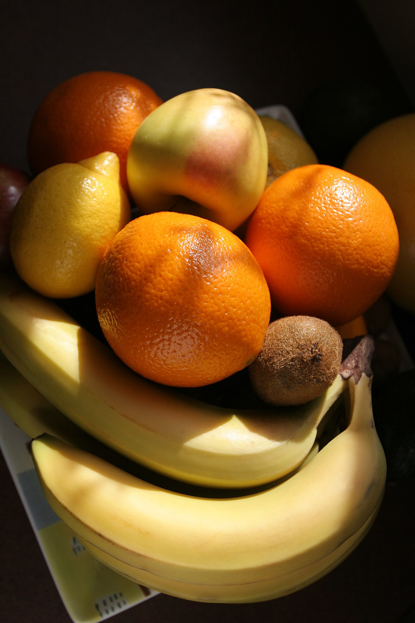

Plate of fruit

### Q1.3

A coin is tossed 4 times. What is the probability that all of them show heads up?

**Step-by-step solution**

Independent flips multiply:
$$P(\text{4 heads}) = \left(\tfrac{1}{2}\right)^4 = \tfrac{1}{16} = 0.0625$$

**Answer:** $1/16 = 6.25\%$.

### Q1.4

In a game, you toss a coin. If it turns up head, you roll a dice deciding how many pieces of candy you will receive. What is the likelihood that you will receive 2 pieces of candy?

**Step-by-step solution**

You only get candy if the coin is heads **and** the dice shows 2:
$$P(\text{2 candies}) = P(\text{head}) \cdot P(\text{dice} = 2) = \tfrac{1}{2} \cdot \tfrac{1}{6} = \tfrac{1}{12}$$

**Answer:** $1/12 \approx 8.3\%$.

### Q1.5

A coin is thrown 3 times. What is the probability that at least one head is obtained?

**Step-by-step solution**

The complement of “at least one head” is “no heads at all”:
$$P(\geq 1 \text{ head}) = 1 - P(\text{0 heads}) = 1 - \left(\tfrac{1}{2}\right)^3 = 1 - \tfrac{1}{8} = \tfrac{7}{8}$$

**Answer:** $7/8 = 87.5\%$. The complement trick is often the easiest way to compute “at least one” probabilities.

### Q1.6

What is the probability of getting a numbered card from a deck of cards?

**Step-by-step solution**

A standard deck has 52 cards. Numbered cards are 2–10, i.e. 9 ranks × 4 suits = 36 cards.
$$P(\text{numbered}) = \frac{36}{52} = \frac{9}{13} \approx 0.692$$

**Answer:** $9/13 \approx 69.2\%$. (Aces, Jacks, Queens, Kings are the non-numbered ones.)

### Q1.7

If throwing two dice, what is the likelihood that their sum is 3?

> *Hint:* draw all possibilities as a 6×6 table, count the entries with sum 3.

**Step-by-step solution**

Total outcomes: $6 \times 6 = 36$, all equally likely.

Outcomes summing to 3: $(1,2)$ and $(2,1)$ — that’s 2 outcomes.

$$P(\text{sum} = 3) = \tfrac{2}{36} = \tfrac{1}{18} \approx 5.6\%$$

### Q1.8

Using R, what is the likelihood that the sum of 4 dice sums up to 10?

> *Hints:* nested for-loops, see [example of nested loops](https://bookdown.org/yundai09/rbootcamp/loops.html#nested-loops).

**Step-by-step solution**

```r
count <- 0
total <- 0
for (a in 1:6) {
  for (b in 1:6) {
    for (c in 1:6) {
      for (d in 1:6) {
        total <- total + 1
        if (a + b + c + d == 10) count <- count + 1
      }
    }
  }
}
count / total      # 80 / 1296 = 0.0617...
```

**Answer:** $80/1296 = 5/81 \approx 6.17\%$.

(Sanity check by hand: count compositions of 10 into 4 parts, each in $[1,6]$ — by inclusion–exclusion this gives $\binom{9}{3} - 4\binom{3}{3} = 84 - 4 = 80$.)

### Q1.9

You toss a dice twice. What is the probability that you get the same side twice?

> *Hint:* in how many ways is this possible?

**Step-by-step solution**

There are 36 equally likely outcomes. The “same side twice” outcomes are $(1,1), (2,2), \ldots, (6,6)$ — exactly 6 of them.

$$P(\text{same}) = \tfrac{6}{36} = \tfrac{1}{6}$$

Equivalently: the first die can be anything; the second has to match → probability $1/6$.

### Q1.10

You toss a dice twice. What is the probability that you get different sides?

**Step-by-step solution**

**Way (a) — count directly:** of the 36 outcomes, $36 - 6 = 30$ have different sides → $30/36 = 5/6$.

**Way (b) — use Q1.9 + the complement rule:**
$$P(\text{different}) = 1 - P(\text{same}) = 1 - \tfrac{1}{6} = \tfrac{5}{6}$$

Way (b) is usually the simpler one once you know the complement of the event you’ve already computed.

### Q1.11

Two persons (A and B) are asked to solve a problem. $P(A \text{ solves}) = 0.1$ and $P(B \text{ solves}) = 0.2$. What is $P(A \text{ or } B \text{ solves})$?

> *Hint:* What is the probability that neither solves it?

**Step-by-step solution**

Assume A and B are independent.

$$P(\text{neither}) = (1 - 0.1)(1 - 0.2) = 0.9 \cdot 0.8 = 0.72$$

$$P(A \text{ or } B) = 1 - P(\text{neither}) = 1 - 0.72 = 0.28$$

**Answer:** 28%.

(Equivalent direct computation: $P(A) + P(B) - P(A \text{ and } B) = 0.1 + 0.2 - 0.1\cdot 0.2 = 0.28$.)

- Optional: counting-type probability questions: https://thirdspacelearning.com/blog/probability-questions.
- Optional: harder questions: https://www.hitbullseye.com/Probability-Examples.php.

## Recap: Expected value / Expectation

**Introduction:** If you win 100$ if the coin turns heads up, what do you win on average? This is called expected value, and will become especially relevant once we get into statistics in Module 4!

- If $X$ is the random variable denoting the outcome of playing, then the expectation (or expected value) is denoted $E[X]$.
- The definition for a discrete variable is $E[X] = \sum_i p(i) X_i$, where the sum is over all possible events.
- When we get to statistics in Module 4, we will also consider the continuous equivalent: $E[X] = \int_{-\infty}^{\infty} x f(x)\, dx$.
- Here is a video solving some examples: https://www.youtube.com/watch?v=b6VK2VPMXNI.

**Practise expected value:**

### Q2.1

Assume you win 100$ if the coin turns heads up, but have to pay 50$ otherwise. What do you win on average per coin flip?

**Step-by-step solution**

$$E[X] = \tfrac{1}{2}\cdot 100 + \tfrac{1}{2}\cdot(-50) = 50 - 25 = 25$$

**Answer:** $25 per flip on average.

### Q2.2

Assume you roll a dice and win 100$ if you get a 6; but you have to pay 20$ if you get an odd number. What do you win on average per dice toss?

**Step-by-step solution**

Three cases: a 6 (prob $1/6$, payoff +100), an odd number 1/3/5 (prob $3/6$, payoff −20), an even number 2/4 (prob $2/6$, payoff 0).

$$E[X] = \tfrac{1}{6}\cdot 100 + \tfrac{3}{6}\cdot(-20) + \tfrac{2}{6}\cdot 0 = \tfrac{100 - 60}{6} = \tfrac{40}{6} \approx 6.67$$

**Answer:** $6.67 per toss on average.

### Q2.3

You offer people to win 10$ times the number of dots on a dice they throw. What is the least they should pay to play, for you to break even on average?

**Step-by-step solution**

$$E[10 \cdot \text{dice}] = 10 \cdot \frac{1+2+3+4+5+6}{6} = 10 \cdot \frac{21}{6} = 35$$

**Answer:** they must pay at least $35 per play for you to break even on average.

### Q2.4

You flip a coin and you either gain 50$ or lose 100$. However, instead of gaining 50$, you get the option to flip again, and either gain 200$, or lose 150$.

1. Assuming you already won 50$, would you flip the coin again?
2. If you are offered to play, and you pick the optimal strategy, what would you win or lose on average?

**Step-by-step solution**

**a.** Compare the certain 50$ to the expected value of re-flipping:
$$E[\text{reflip}] = \tfrac{1}{2}\cdot 200 + \tfrac{1}{2}\cdot(-150) = 100 - 75 = 25$$

50 > 25, so **don’t reflip** — keep the 50$.

**b.** With the optimal strategy (never reflip), the game is just the original coin flip:
$$E[\text{game}] = \tfrac{1}{2}\cdot 50 + \tfrac{1}{2}\cdot(-100) = 25 - 50 = -25$$

**Answer:** you lose $25 on average per game. (You should refuse to play.)

## Markov chains

**A fun and very useful application of probability theory combined with linear algebra:** Imagine a game at a casino where you repeatedly flip a coin. If you get heads up, you gain one more coin. Otherwise, you lose one coin. What is the chance that you will ruin the casino? This can easily be solved using Markov chain theory, a powerful application of pure probability theory combined with rather basic linear algebra. It is used to model many phenomena, including diffusion of molecules inside cells.

- This video has great visualizations of the core concepts. It also introduces you to how Markov chain modeling of the web (the PageRank algorithm) led to the creation of Google. **The first 8 minutes is enough** but to get a full appreciation of their power, by all means, check the full video! https://www.youtube.com/watch?v=JGQe4kiPnrU
- Optional: all the details are also covered here, although in a very condensed format: https://www.stat.auckland.ac.nz/~fewster/325/notes/ch8.pdf.
- Wikipedia has some [Markov chain examples](https://en.wikipedia.org/wiki/Examples_of_Markov_chains).
- Finally, we have written a Markov chain visual simulator that you can play with if you want: http://demo-markovchain.serve.scilifelab.se.

In short:

- The probability of moving from state $i$ to state $j$ in one single step can be read out from the matrix $P$, at row $i$, column $j$.
- $\pi(t=0) = \begin{bmatrix} \pi_1 & \pi_2 & \pi_3 & \cdots & \pi_n \end{bmatrix}$ are the probabilities of starting in any of the states $1\ldots n$.
- You can compute the probability of being in a state after $k$ jumps as $\pi(t=k) = \pi(t=0)\, P^k$.

**Practice Markov chains:**

Consider the following Markov chain:

```
%%| fig-cap: "Weather Markov chain"
stateDiagram-v2
    direction LR
    Sunny --> Sunny: 0.1
    Sunny --> Rain: 0.9
    Rain --> Sunny: 0.5
    Rain --> Rain: 0.5
```

### Q3.1

Intuitively, do you expect good or bad weather?

**Step-by-step solution**

Compare the self-loops: Sunny stays sunny with only **0.1**, while Rain stays rainy with **0.5**. So once it rains it tends to keep raining, but a sunny day flips to rain with 0.9 probability.

### Q3.2

Write the transition matrix.

**Step-by-step solution**

With the state order (Sunny, Rain), read each arrow off the diagram:

$$P = \begin{bmatrix} 0.1 & 0.9 \\ 0.5 & 0.5 \end{bmatrix}$$

Row 1 (from Sunny): stay sunny 0.1, switch to rain 0.9. Row 2 (from Rain): switch to sunny 0.5, stay rainy 0.5. Each row sums to 1, as it must.

### Q3.3

Draw the Markov chain of continuously flipping a coin (how many and which states are there? probabilities of going between them?).

**Step-by-step solution**

Two states: **H** (heads) and **T** (tails). Each flip is independent of the previous one, so from either state you go to H with probability $1/2$ and to T with probability $1/2$.

```
        0.5
   ┌───────────┐
   ▼           │
  ┌───┐  0.5  ┌───┐
  │ H │ ────▶ │ T │
  │   │ ◀──── │   │
  └───┘  0.5  └───┘
   │           ▲
   └───────────┘
        0.5
```

### Q3.4

Write the transition matrix (for the coin chain in Q3.3).

**Step-by-step solution**

With the order (H, T):

$$P = \begin{bmatrix} 0.5 & 0.5 \\ 0.5 & 0.5 \end{bmatrix}$$

Each row sums to 1, as it must.

Consider the following Markov chain:

```
%%| fig-cap: "3-state Markov chain"
stateDiagram-v2
    direction LR
    S1 --> S2: 0.5
    S1 --> S3: 0.5
    S2 --> S1: 0.1
    S2 --> S3: 0.9
    S3 --> S2: 0.8
    S3 --> S1: 0.2
```

### Q3.5

What is the probability of going from state 2 to state 3 in one step?

**Step-by-step solution**

Read $P_{2,3}$ directly off the diagram — the probability on the arrow $S_2 \to S_3$:

$$P_{2,3} = 0.9$$

### Q3.6

Write the transition matrix.

**Step-by-step solution**

With state order $(S_1, S_2, S_3)$ and reading each arrow off the diagram:

$$P = \begin{bmatrix} 0 & 0.5 & 0.5 \\ 0.1 & 0 & 0.9 \\ 0.2 & 0.8 & 0 \end{bmatrix}$$

Each row sums to 1. The zeros on the diagonal reflect that no state has a self-loop in this chain.

### Q3.7

What is the probability of going from state 2 to state 3 in two steps?

> *Hints:* this can be read out of $P^2$; you can also derive it from conditional probability from scratch. To verify the answer, use `%*%` in R to multiply matrices. There is an intuitive answer: what possible ways are there to go from 2 to 3 in two steps?

**Step-by-step solution**

**Method 1 — by hand (enumerate paths):** in 2 steps from $S_2$ to $S_3$, the only intermediate states are $S_1$, $S_2$, or $S_3$. But $P_{2,2} = 0$ and $P_{3,3} = 0$, so only the path $S_2 \to S_1 \to S_3$ contributes:

$$P(2 \to 3 \text{ in 2 steps}) = P_{2,1}\cdot P_{1,3} = 0.1 \cdot 0.5 = 0.05$$

**Method 2 — matrix:** the same number is entry $(2,3)$ of $P^2$:

$$P^2 = \begin{bmatrix} 0.15 & 0.40 & 0.45 \\ 0.18 & 0.77 & 0.05 \\ 0.08 & 0.10 & 0.82 \end{bmatrix}$$

In R:

```r
P <- matrix(c(0, 0.5, 0.5,
              0.1, 0,   0.9,
              0.2, 0.8, 0), 3, 3, byrow = TRUE)
(P %*% P)[2, 3]      # 0.05
```

**Answer:** $0.05$.

### Q3.8

What is the probability of going from state 1 to state 3 in 3 steps?

**Step-by-step solution**

It is entry $(1,3)$ of $P^3$:
$$(P^3)_{1,3} = \sum_k (P^2)_{1,k} \cdot P_{k,3} = 0.15 \cdot 0.5 + 0.40 \cdot 0.9 + 0.45 \cdot 0 = 0.435$$

In R:

```r
P3 <- P %*% P %*% P
P3[1, 3]      # 0.435
```

**Answer:** $0.435$.

### Q3.9

What is the *stationary distribution* for the Markov chain?

The video introduced the *stationary state/distribution*, which is when the probability of being in a certain state does not change after taking one more step. In other words, it is a stable point. Markov chains that furthermore always converge to a stable state are called *ergodic*.

Remember that stationary state is when $\pi P = \pi$ and $\sum_i \pi_i = 1$ (by definition — what is the intuitive interpretation of this equation?).

You can get the first matrix equation into a more familiar form by rewriting as $\pi(P - \mathbb{I}) = 0$ and simplifying it.

You note that the vector is in an inconvenient place for Gaussian elimination. Sweat not, as you can swap the order: $0 = 0^T = (AB)^T = B^T A^T$, where $T$ denotes the [transpose](https://en.wikipedia.org/wiki/Transpose).

*Hint #2:* To get full rank (i.e. be able to get a unique answer), you need to make use of the normalizing condition (that all probabilities sum to 100%). It can be rewritten as
$$\begin{bmatrix} 1 & 1 & \cdots \end{bmatrix} \begin{bmatrix} \pi_1 \\ \pi_2 \\ \vdots \end{bmatrix} = \begin{bmatrix} 1 \end{bmatrix}$$
and added to the first system of equations.

If the above is confusing, simply solve it without using matrices. They are not needed for such a small problem.

**Step-by-step solution**

For the 3-state chain $P = \begin{bmatrix} 0 & 0.5 & 0.5 \\ 0.1 & 0 & 0.9 \\ 0.2 & 0.8 & 0 \end{bmatrix}$, write $\pi P = \pi$ with $\pi = (\pi_1, \pi_2, \pi_3)$. This gives three equations:

$$\begin{aligned}
0.1\,\pi_2 + 0.2\,\pi_3 &= \pi_1 \\
0.5\,\pi_1 + 0.8\,\pi_3 &= \pi_2 \\
0.5\,\pi_1 + 0.9\,\pi_2 &= \pi_3
\end{aligned}$$

Substitute (1) into (2): $0.05\,\pi_2 + 0.9\,\pi_3 = \pi_2 \Longrightarrow \pi_3 = \tfrac{19}{18}\pi_2$.

Plug back into (1): $\pi_1 = 0.1\,\pi_2 + 0.2 \cdot \tfrac{19}{18}\pi_2 = \tfrac{14}{45}\pi_2$.

Normalize with $\pi_1 + \pi_2 + \pi_3 = 1$:
$$\left(\tfrac{14}{45} + 1 + \tfrac{19}{18}\right)\pi_2 = \tfrac{213}{90}\,\pi_2 = 1 \;\Longrightarrow\; \pi_2 = \tfrac{90}{213} = \tfrac{30}{71}$$

So:
$$\pi = \left(\tfrac{28}{213},\; \tfrac{90}{213},\; \tfrac{95}{213}\right) \approx (0.131,\; 0.423,\; 0.446)$$

**Answer:** in the long run the chain spends ≈ 13% of the time in $S_1$, 42% in $S_2$, 45% in $S_3$.

Sanity check in R using powers of $P$:

```r
P <- matrix(c(0,   0.5, 0.5,
              0.1, 0,   0.9,
              0.2, 0.8, 0), 3, 3, byrow = TRUE)
P100 <- P
for (i in 1:99) P100 <- P100 %*% P
P100        # every row should be ≈ (0.131, 0.423, 0.446)
```

(For ergodic chains, $\pi(t=k)$ converges to the stationary distribution regardless of starting state.)

### Q3.10

Optional: solve problem 1 here: https://www.probabilitycourse.com/chapter11/11_2_7_solved_probs.php (the other problems are beyond this course).

**Optional deeper reading:** You can see how to model, for example, the continuous coin flip game here: https://physiology.med.cornell.edu/people/banfelder/qbio/resources_2016/S.1_markov.pdf.